# Species distribution modeling in R: an example with spadefoot toads

March 2, 2015

## What is Species Distribution Modeling?

- statistically predict species distribution based on known occurrences and environmental data
- useful for:
  - predicting new localities
  - understanding climatic niche
  - predicting past and future distributions

[figure not shown]

## Doing SDM in MaxEnt

- MaxEnt: Maximum entropy
- Generally accepted as the best model for presence-only datasets
- 3 inputs: occurrence points, background points, environmental layers
- program examines environmental values at occurrence points and background points
- outputs: prediction map, stats on environmental variable importance and model fit

[figure not shown]

## Why am I doing it?

- Spea hammondii - western spadefoot toad

[figure not shown]

## Why am I doing it?

- *spadefoot*

[figure not shown]

## Why am I doing it?

- understand environmental contributions to range limit
- predict range shift under different climate scenarios
- estimate past range to explore ancient hybridization with currently-allopatric congeners
- all part of a broader PhD dissertation on landscape genomics of Spea hammondii

## Getting and manipulating data

- One of the biggest challenges of running species distribution models is getting data in the proper format
- getting appropriate data points, using proper formatting, equivalent spatial projections, equal raster extent, consistent file names,…

## Species occurrence points

- GBIF (Global Biodiversity Information Facility)
- raw GBIF data: 940 occurrences, 208 variables…
  - challenge: how do we go from this raw data to the data we need?
  - How do we check that all the points are actually our species of interest?
- all we need are two variables: longitude and latitude

```r
head(speaGBIFraw)
```

```
##      gbifID abstract
## 1 657433321       NA
## 2 657433331       NA
## 3  45094283       NA
## 4 657433310       NA
## 5  44914022       NA
## 6  45097694       NA
##                                             accessRights accrualMethod
## 1 http://www.nhm.org/site/about-our-museums/terms-of-use            NA
## 2 http://www.nhm.org/site/about-our-museums/terms-of-use            NA
## 3                                                                   NA
## 4 http://www.nhm.org/site/about-our-museums/terms-of-use            NA
## 5                                                                   NA
## 6                                                                   NA
##   accrualPeriodicity accrualPolicy alternative audience available
```

[output cut: 391 more lines]

## Cleaning up occurrence points

- built a function to clean up raw GBIF output

```r
gbifclean <- function(gbifraw) {
  latcol <- grep("decimal[Ll]atitude", colnames(gbifraw)) #returns column number for Latitude values
  longcol <- grep("decimal[Ll]ongitude", colnames(gbifraw)) #returns column number for Longitude values
  namecol <- grep("^scientificName$", colnames(gbifraw)) #returns column number for species name(s)
  latlong <- gbifraw[,c(namecol, longcol, latcol)] #subsets the input data to just these 3 columns
  colnames(latlong)[2] <- "Longitude" #changes column name to "Longitude"
  colnames(latlong)[3] <- "Latitude" #changes column name to "Latitude"
  latlong[,1] <- "Spea hammondii" #Converts names in column 1 to proper name
  latlong <- latlong[complete.cases(latlong), ] #removes rows with any missing data
  latlong[,2] <- abs(latlong[,2]) * -1 #ensures that longitude values are negative; use as appropriate for region
  latlong[,3] <- abs(latlong[,3]) #ensures that latitude values are positive; use as appropriate for region
  latlong #prints fixed data at the end to be put into new object
}
```

- complete.cases() is a nifty function that returns row numbers that have no missing data
  - can use to remove rows with missing data and put into new object

## Cleaning up occurrence points

```r
gbifclean(speaGBIFraw) #runs the clean-up function
```

```
##     scientificName Longitude Latitude
## 1   Spea hammondii -117.7239 33.61086
## 2   Spea hammondii -117.6955 33.62504
## 4   Spea hammondii -118.3506 33.91631
## 7   Spea hammondii -117.1074 33.91942
## 8   Spea hammondii -117.4366 33.75802
## 9   Spea hammondii -117.1074 33.91942
## 10  Spea hammondii -117.1074 33.91942
## 12  Spea hammondii -117.1074 33.91942
## 14  Spea hammondii -116.6617 31.71833
## 17  Spea hammondii -117.5683 33.43594
## 18  Spea hammondii -118.4342 34.05072
## 19  Spea hammondii -117.7128 33.47001
## 20  Spea hammondii -117.9896 33.75918
## 21  Spea hammondii -116.6617 31.71833
```

[output cut: 777 more lines]

```r
head(speaGBIFclean)
```

```
##   scientificName Longitude Latitude
## 1 Spea hammondii -117.7239 33.61086
## 2 Spea hammondii -117.6955 33.62504
## 4 Spea hammondii -118.3506 33.91631
## 7 Spea hammondii -117.1074 33.91942
## 8 Spea hammondii -117.4366 33.75802
## 9 Spea hammondii -117.1074 33.91942
```

Much better!

## Cleaning up occurrence points

## What about spatially-aberrant points?

- congeners look very similar
- Spea hammondii was somewhat recently split (into S. hammondii and S. multiplicata), so some older records may be uncorrected S. multiplicata (the two species do not overlap)
- range is well-known so can easily ID outliers

## Plotting occurrence points

- function to plot/visualize occurrence points
- automatically limits map extent to area of occurrence points

```r
plotgbifclean <- function(latlong) {
  data(wrld_simpl) #loads world map
  xlowlim <- min(latlong$Longitude) - 0 #uses values in data to set appropriate limits on plot axes
  xuplim <- max(latlong$Longitude) + 0
  ylowlim <- min(latlong$Latitude) - 0
  yuplim <- max(latlong$Latitude) + 0
  plot(wrld_simpl, xlim = c(xlowlim, xuplim), ylim = c(ylowlim, yuplim), axes=TRUE, ylab="Latitude", xlab="Longitude", cex.axis=0.7)
  points(latlong$Longitude, latlong$Latitude, col='purple', pch=20, cex=0.75) #adds points to map
  box() #puts box around plot
}
```

## Plotting occurrence points

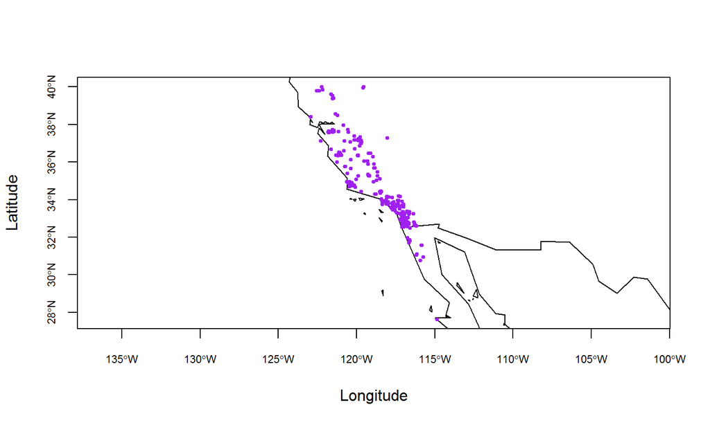

```r
par(mfrow=c(1,1))
plotgbifclean(speaGBIFclean) #executes plotting function
```

## Plotting occurrence points

- remove points outside range likely to be records of other, similar species

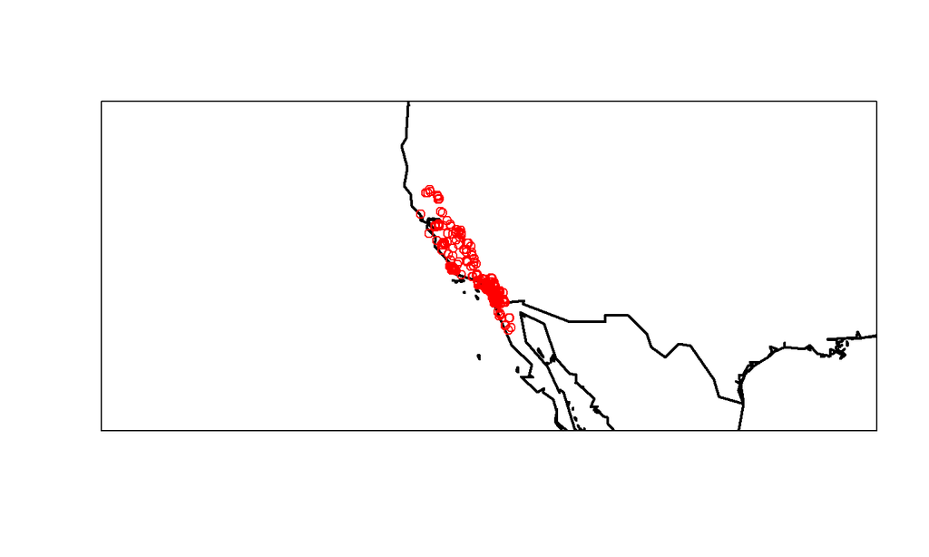

```r
speaLocfix <- subset(spealoc, subset=((Latitude > 28.5) & (Longitude < -120 | Latitude < 39.3) & (Longitude < -118.5 | Latitude < 36.7)))
#clips out points that do not fall in expected range
par(mfrow=c(1,1))
plot(wrld_simpl, border="black", lwd=2, xlim=c(-125,-110), ylim=c(25,45))
points(speaLocfix, col="red")
box()
```

## Subsampling occurrence points

- Differential sampling can bias the model (numerous published studies on this)
- Divide area into grid and sample one occurrence point per grid

## Subsampling occurrence points

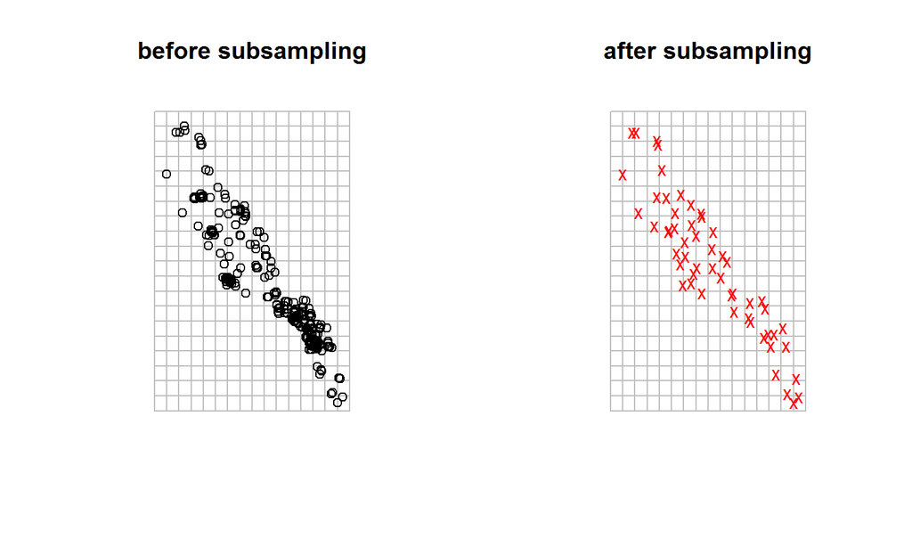

```r
speasel <- gridSample(speaspdf, r, n=1) #produces subsample of n=1 point from each raster grid; this will be occurrence data input
p <- rasterToPolygons(r)
par(mfrow=c(1,2))
plot(p, border='gray', main="before subsampling")
points(speaspdf)
plot(p, border='gray', main="after subsampling")
points(speasel, cex=1, col='red', pch='x')
```

## Environmental layers

- Bioclim variables: biologically-relevant measures of climate
  - Bio1 to Bio19
  - e.g. Annual mean temperature (bio1), min temp. of coldest month (bio6), annual precip (bio12), precip of warmest quarter (bio18), etc.

## Environmental layers

- downloading layers and cropping to relevant area:
- "getData()" function in "raster" package; only works for current environmental layers

```r
BClim2_5 = getData("worldclim", var="bio", res=2.5, path="bioclim2.5/") #download 19 bioclim variables, 2.5arcmin resolution
ShamRangenarrow = extent(-125.5, -110, 25, 45) #crop Bioclim layers to this extent
bclim2.5Shamnarrow = crop(BClim2_5, ShamRangenarrow)
writeRaster(bclim2.5Shamnarrow, filename="bioclim2.5/ShamnarrowBC_2.5.grd", overwrite=T)
bclim2.5Shamnarrow = brick("bioclim2.5/ShamnarrowBC_2.5.grd")
```

## Past and present environmental layers

- can project model fit to current climate data to other climate layers
- more convoluted process for downloading bioclim layers from past and future
  - download from worldclim site as GeoTIFF, import as raster and crop, convert format, change filenames to match current filenames, make RasterStack object

```r
makeprojlayers <- function(directories) { #function to take downloaded future layers and get them to proper format for running maxent...
  for (i in 1:length(directories)) {
    setwd(directories[i])
    projtifs <- list.files() #directory is set before running function with setwd()
    projtifs <- projtifs[c(1,12,13,14,15,16,17,18,19,2,3,4,5,6,7,8,9,10,11)]

    for (i in 1:19) {
      crop(raster(projtifs[i]), ShamRangenarrow, filename=paste("bio",i,".tif", sep=""), overwrite=TRUE)
    }
    projtifsbio <- list.files(pattern="bio")
    projtifsbio <- projtifsbio[c(1,12,13,14,15,16,17,18,19,2,3,4,5,6,7,8,9,10,11)] #reorders appropriately... ugh

    for (i in 1:19) {
      writeRaster(raster(projtifsbio[i]), filename=paste("bio",i,".bil",sep=""), format="EHdr")
   }
    if (list.files(pattern="bio1.bil$") == "bio1.bil") {
      cat(".bil rasters successfully created", sep=" ")
    }
  }
  setwd(homedir)
}
```

## Bioclim layers

- each raster contains a range of values over the map area used in the model
- imagine all stacked and taking value at a point on top of all - that occurrence point corresponds to a value in all 19 of these layers

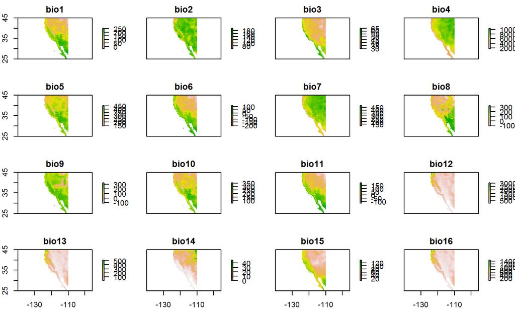

```r
par(mfrow=c(1,1))
plot(bclim2.5Shamnarrow) #plots the bioclim raster layers
```

## the Maxent model!

- "dismo" package allows one to run MaxEnt through R
- MaxEnt also available as a GUI, but less efficient if doing multiple analyses
- MaxEnt uses environmental values at occurrence points to train the model to predict probability of occurrence based on environmental variables
- Background points across the raster used to sample environmental space that excludes target species

## occurrence and background

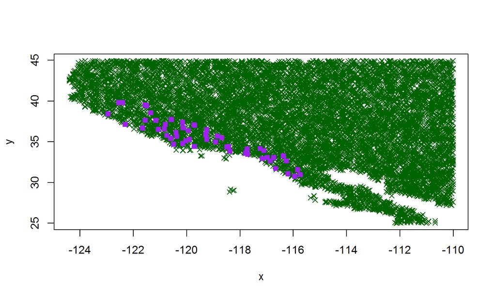

```r
par(mfrow=c(1,1))
bg <- randomPoints(bclim2.5Shamnarrow, 10000) #pulls random background points from extent of raster
plot(bg, col="dark green", pch=4) #plots background points
points(speasel, col="purple", pch=15) #plots occurrence points
```

## Running the MaxEnt model and plotting the results

```r
maxentpresent_randombg <- maxent(bclim2.5Shamnarrow, speasel, a=bg, path="maxentrun_randombg", args=c("-J", "-P"))
predpresrandombg <- predict(maxentpresent_randombg, bclim2.5Shamnarrow) #predict() actually makes the prediction map
plot(predpresrandombg, main="Current modeled distribution")
plot(maxentpresent_randombg, main="bioclim variable contribution")
```

- In addition to prediction maps, can use other methods to test model fit and significance
  - Cross-validation (divide occurrence points into test and training data)
  - subsampling without replacement
  - bootstrapping (with replacement)

## Jackknifing

- iteratively omit each variable and re-run model to test environmental variable importance
- can see bio18 (precip of warmest quarter) by itself is the best predictor variable in the model

[figure not shown]

## prediction map

[figure not shown]

## variable contributions

- bio18: precip of warmest quarter
- bio19: precip of coldest quarter
- bio14: precip of driest month
- bio15: precip seasonality (coeff. of variation)

[figure not shown]

## Run model for other scenarios

[figure not shown]